# Playing Around With Survival Analysis - 1

## Objective:

1. Estimate survival function estimate for given time-to-event data. Here, event considered is a binary event.
2. Compare survival curve estimates for 2 segments of data.

## Solution:

We can use `survival` package to accomplish this.

1. `Surv` function to get the data in the right format.
2. which will then be passed tp `survfit` function to compute simple Kaplan-Meier estimator.
3. `survdiff` function to test if difference between 2 survival functions is significant.

## Code:

```r
# install.packages("OIsurv")
# install.packages("survsim")
# install.packages("broom")
library(OIsurv)
# library(help=KMsurv)
library(dplyr)
```

```r
library(broom)
library(ggplot2)
library(survsim)
# Real dataset (From KMSurv package)
# help(tongue)
data(tongue)
head(tongue)
```

```
##   type time delta
## 1    1    1     1
## 2    1    3     1
## 3    1    3     1
## 4    1    4     1
## 5    1   10     1
## 6    1   13     1
```

```r
summary(tongue)
```

```
##       type           time            delta
##  Min.   :1.00   Min.   :  1.00   Min.   :0.0000
##  1st Qu.:1.00   1st Qu.: 23.75   1st Qu.:0.0000
##  Median :1.00   Median : 69.50   Median :1.0000
##  Mean   :1.35   Mean   : 73.83   Mean   :0.6625
##  3rd Qu.:2.00   3rd Qu.:101.75   3rd Qu.:1.0000
##  Max.   :2.00   Max.   :400.00   Max.   :1.0000
```

This dataset is about 80 male subjects who were diagnosed with one of the 2 types of cancer of the tongue. Time tp death is expressed in weeks. More info on this can be found from the package documentation for this dataset using `help(tongue)`.

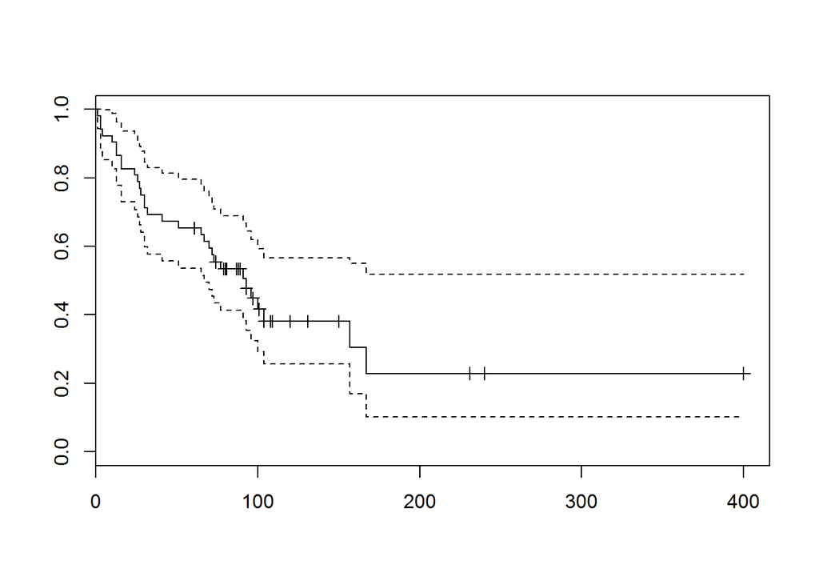

```r
# Analyzing just one type of tumor (Aneuploid Tumor)
tongue2 = tongue %>%
  filter(type == 1)

# Converting into a Surv object
tongue2_surv <- Surv(tongue2$time, tongue2$delta)

# Getting KM estimator
tongue2_survfit = survfit(tongue2_surv ~ 1)
plot(tongue2_survfit)
```

- The above plot shows Kaplan Meier estimator of the survival function (solid line) along with the confidence interval (dotted lines).
- The `+` signs represent censoring i.e. subjects for whom we don’t have any readings available after that week. The only thing we know is the subject didn’t die until that point in time.

```r
glance(tongue2_survfit)
```

```
##   records n.max n.start events median conf.low conf.high
## 1      52    52      52     31     93       67        NA
```

The median value of 93 implies, 50% of the subjects died within 93 weeks of diagnosis.

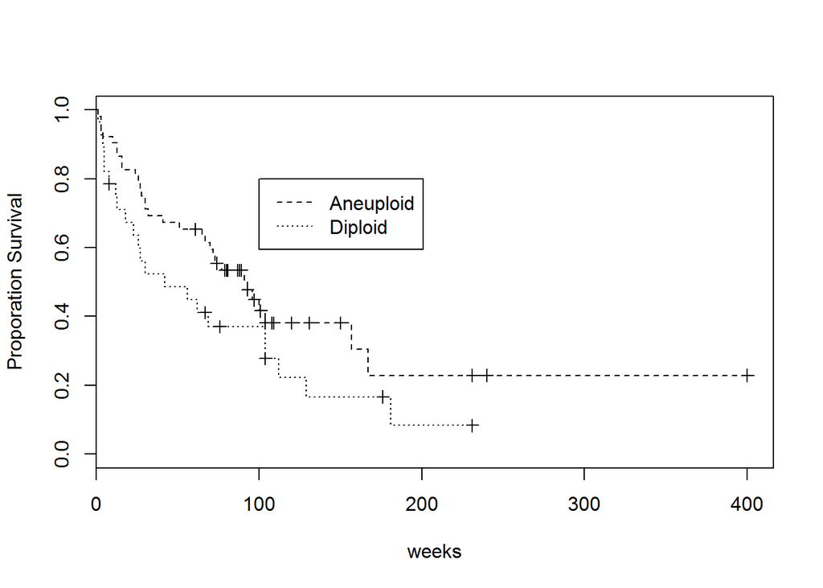

```r
# Graphically Comparing KM estimator for 2 tumors
tongue_survfit = survfit(Surv(time = time, event = delta) ~ type, data = tongue)
plot(tongue_survfit, lty = 2:3, xlab = "weeks", ylab = "Proporation Survival")
legend(100, .8, c("Aneuploid", "Diploid"), lty = 2:3)
```

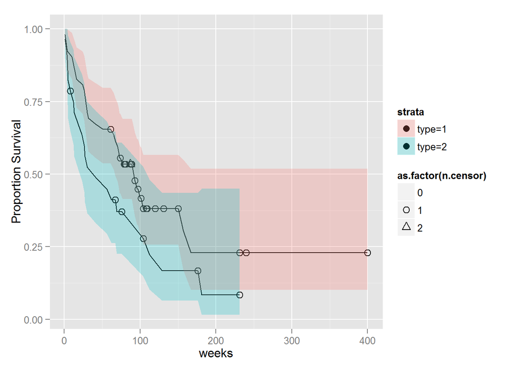

```r
# ggplot2 version of the plot
tongue_tidy = tidy(tongue_survfit)
mx = max(tongue_tidy$n.censor)
ggplot(tongue_tidy, aes(time, estimate, fill = strata)) +
  geom_line() +
  geom_point(aes(shape = as.factor(n.censor)), size = 3) +
  scale_shape_manual(values=c(NA, 1:mx))+
  geom_ribbon(aes(ymin=conf.low, ymax=conf.high), alpha=.25) +
  xlab("weeks") +
  ylab("Proportion Survival")
```

We can compare the survival curves using various statistical tests using `survdiff` function. Apart from the usual formula and data arguments it takes `rho` is an argument. Setting different values of `rho` leads to different kinds of test. In general -

- `rho` > 0 implies higher weight is given to initial part of the survival curve
- `rho` < 0 implies higher weight is given to latter part of the survival curve Depending on the value of rho we can get different results as can be seen in the below example.

```r
# Statistical tests for comparison
survdiff(Surv(time = time, event = delta) ~ type, data = tongue, rho = 0) # log-rank, default
```

```
## Call:
## survdiff(formula = Surv(time = time, event = delta) ~ type, data = tongue,
##     rho = 0)
##
##         N Observed Expected (O-E)^2/E (O-E)^2/V
## type=1 52       31     36.6     0.843      2.79
## type=2 28       22     16.4     1.873      2.79
##
##  Chisq= 2.8  on 1 degrees of freedom, p= 0.0949
```

```r
survdiff(Surv(time = time, event = delta) ~ type, data = tongue, rho = 1)
```

```
## Call:
## survdiff(formula = Surv(time = time, event = delta) ~ type, data = tongue,
##     rho = 1)
##
##         N Observed Expected (O-E)^2/E (O-E)^2/V
## type=1 52     20.2     24.4     0.731       3.3
## type=2 28     15.1     10.9     1.643       3.3
##
##  Chisq= 3.3  on 1 degrees of freedom, p= 0.0694
```

It outputs a chi-squared statistic as well as p-value which can be used to determine whether the difference is significant at certain significance level.

### Simulating a dataset using `simple.surv.sim` function from `survsim` package.

- **Time-to-event:** Assumed to be following weibull distribution with p = 1.5 i.e. the mode of the time to event is closer to median then for exponential distribution (p = 1)
- **Time-to-censoring:** Assumed to be following weibull distribution with p = 10 i.e. censoring is happening mostly in the latter part of the survival curve.
- **Covariate:** 1 Binary covariate with p = .7 and beta of 0.6. (In the following post I’ll try to reverse-engineer this beta using coxph or other similar models)

Following is the same analysis using this simulated dataset. Try and see if you can make sense of code and the output.

```r
set.seed(2365)
d1 = simple.surv.sim(n = 500, foltime = 1000, dist.ev = 'weibull', anc.ev = 1.5, beta0.ev = 2, # event dist - weibull with p = 1.5
                     dist.cens = 'weibull', anc.cens = 10, beta0.cens = 2.01, # censoring dist - weibull with p = 10
#                      z = list(c("weibull", 1)), #assuming independent observations i.e. no within subject correlation
                     beta = list(c(.6)), x = list(c("bern", .7)) # 1 binary covariate
                     )

# View(d1)

summary(d1)
```

```
##
## Number of subjects at risk
## ----------------------------
##   sub.risk
##       500
##
##
## Number of events
## ----------------------------
##   num.events
##         186
##
##
## Proportion of subjects with event
## ----------------------------
##   mean.ep.sub
##        0.372
##
##
## Total time of follow-up
## ----------------------------
##    foltime
##  2964.863
##
##
## Time of follow-up (median)
## ----------------------------
##   med.foltime
##     6.612405
##
##
## Density of incidence
## ----------------------------
##   dens.incid
##  0.06273477
```

```r
summary(as.data.frame(d1))
```

```
##       nid            status          start        stop              z
##  Min.   :  1.0   Min.   :0.000   Min.   :0   Min.   :0.1452   Min.   :1
##  1st Qu.:125.8   1st Qu.:0.000   1st Qu.:0   1st Qu.:4.8752   1st Qu.:1
##  Median :250.5   Median :0.000   Median :0   Median :6.6124   Median :1
##  Mean   :250.5   Mean   :0.372   Mean   :0   Mean   :5.9297   Mean   :1
##  3rd Qu.:375.2   3rd Qu.:1.000   3rd Qu.:0   3rd Qu.:7.4102   3rd Qu.:1
##  Max.   :500.0   Max.   :1.000   Max.   :0   Max.   :9.1243   Max.   :1
##        x
##  Min.   :0.000
##  1st Qu.:0.000
##  Median :1.000
##  Mean   :0.714
##  3rd Qu.:1.000
##  Max.   :1.000
```

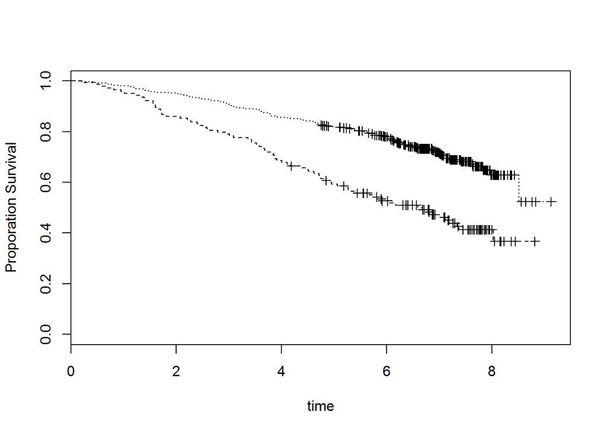

```r
d1_survfit = survfit(Surv(time = start, time2 = stop, event = status) ~ x, data = d1)
d1_survfit = survfit(Surv(time = stop, event = status) ~ x, data = d1) # same as above

plot(d1_survfit, lty = 2:3, xlab = "time", ylab = "Proporation Survival")
legend(100, .8, c("x=0", "x=1"), lty = 2:3)
```

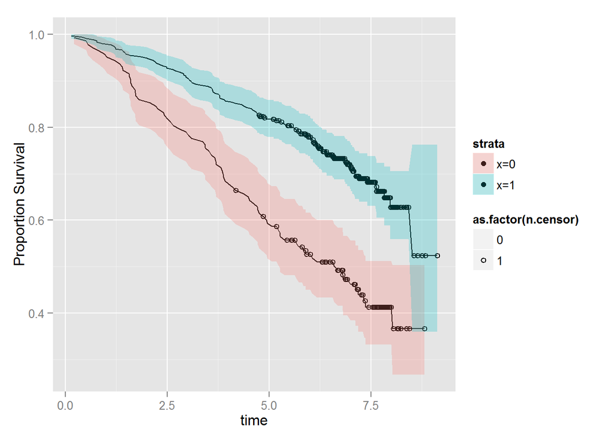

```r
# ggplot2 version of the plot
d1_tidy = tidy(d1_survfit)
mx = max(d1_tidy$n.censor)
ggplot(d1_tidy, aes(time, estimate, fill = strata)) +
  geom_line() +
  geom_point(aes(shape = as.factor(n.censor)), size = 2) +
  scale_shape_manual(values=c(NA, 1:mx))+
  geom_ribbon(aes(ymin=conf.low, ymax=conf.high), alpha=.25) +
  xlab("time") +
  ylab("Proportion Survival")
```

```r
# Statistical tests for comparison
survdiff(Surv(time = stop, event = status) ~ x, data = d1, rho = 0)
```

```
## Call:
## survdiff(formula = Surv(time = stop, event = status) ~ x, data = d1,
##     rho = 0)
##
##       N Observed Expected (O-E)^2/E (O-E)^2/V
## x=0 143       79     45.7     24.30      32.3
## x=1 357      107    140.3      7.91      32.3
##
##  Chisq= 32.3  on 1 degrees of freedom, p= 1.31e-08
```

## References:

- http://anson.ucdavis.edu/~hiwang/teaching/10fall/R_tutorial%201.pdf
- http://www.utstat.utoronto.ca/reid/sta442f/2009/fox-survival.pdf
- http://www.jstatsoft.org/v59/i02/paper